# Multivariate Regression and OLS

EC 325: Econometrics

Prof. Caraher

Colby College

Oct 7, 2026

# From Bivariate to Multivariate OLS

## Where We’ve Been

- Last unit: **bivariate OLS**, $y = \beta_0 + \beta_1 x + \mu$, is **unbiased** when GM assumptions 1–4 hold
- The hardest to satisfy is **GM4**, $E[\mu | x] = 0$: *everything else* affecting $y$ must be uncorrelated with $x$ — almost never true in observational data!

**Example:** $wage = \beta_0 + \beta_1 \cdot educ + \mu$

- The error term $\mu$ contains: ability, family connections, motivation, experience, etc.
- Many of these are **correlated with education** — wealthier families → more education *and* higher wages, i.e. $E[\mu | X] \neq 0$

**The Core Problem**

If confounders are in $\mu$ and correlated with $x$, then $E[\mu | x] \neq 0$ and $\hat{\beta}_1$ is **biased**.

# The Multivariate Model

## The Solution: Control for Confounders

- **Today:** how adding **control variables** gets us closer to **causal** estimates
- If family income confounds the education-wage relationship, **include it**:

$$wage = \beta_0 + \beta_1 \cdot educ + \beta_2 \cdot family\_income + \mu$$

- Now $\beta_1$ is the effect of education **holding family income constant**
- Family income is no longer in $\mu$ — that source of bias is gone!
- In general, with $k$ independent variables:

$$y = \beta_0 + \beta_1 x_1 + \beta_2 x_2 + \cdots + \beta_k x_k + \mu$$

- $\mu$ now only contains factors **not included** in the model

## Interpreting Coefficients

- Each coefficient has a **ceteris paribus** interpretation: $\beta_j = \dfrac{\partial y}{\partial x_j}$
- The change in $y$ for a one-unit increase in $x_j$, **holding all other $x$’s constant**
- This is the key difference from bivariate OLS!
  - Bivariate: “associated with” (everything else floating)
  - Multivariate: “holding constant” (the other $x$’s **in the model**)

**Example:** $wage = \beta_0 + \beta_1 \cdot educ + \beta_2 \cdot family\_income + \mu$

- $\beta_1$: Each additional year of education is associated with $\beta_1$ dollars more in wages, **holding family income constant**
- $\beta_2$: Each additional dollar of family income is associated with $\beta_2$ dollars more in wages, **holding education constant**
- **But** holding the other $x$’s constant is **not** the same as causal: $\hat{\beta}_1$ is causal only if nothing left in $\mu$ (e.g., ability) is correlated with $educ$ — that’s GM4, coming up

## Deriving the Multivariate OLS Estimator

Same logic as bivariate OLS: choose the $\hat{\beta}$s to **minimize the sum of squared residuals**:

$$SSR = \sum\nolimits_{i=1}^{n} (y_i - \hat{\beta}_0 - \hat{\beta}_1 x_{1i} - \hat{\beta}_2 x_{2i} - \cdots - \hat{\beta}_k x_{ki})^2$$

Set the partial derivative with respect to each $\hat{\beta}_j$ equal to zero → $k + 1$ **first-order conditions**. The term in parentheses is the **residual**, $\hat{\mu}_i$:

$$\begin{aligned}
\sum\nolimits_{i=1}^{n}(y_i - \hat{\beta}_0 - \hat{\beta}_1 x_{1i} - \cdots - \hat{\beta}_k x_{ki}) &= \sum\nolimits_{i=1}^{n} \hat{\mu}_i = 0 \\
\sum\nolimits_{i=1}^{n} x_{ji}(y_i - \hat{\beta}_0 - \hat{\beta}_1 x_{1i} - \cdots - \hat{\beta}_k x_{ki}) &= \sum\nolimits_{i=1}^{n} x_{ji} \hat{\mu}_i = 0 \quad \text{for } j = 1, \ldots, k
\end{aligned}$$

- Solving these $k + 1$ equations gives the OLS estimates: tedious and uninsightful by hand (matrix algebra)

# Multivariate OLS in R

## Adding Controls is Easy!

Same `lm()` function — just use `+` to add additional $x$, independent variables:

```r
data(mtcars)
lm_biv   <- lm(mpg ~ hp, data = mtcars)        # bivariate
lm_multi <- lm(mpg ~ hp + wt, data = mtcars)   # add weight as a control

coef(lm_biv)
```

```
(Intercept)          hp
30.09886054 -0.06822828
```

```r
coef(lm_multi)
```

```
(Intercept)          hp          wt
37.22727012 -0.03177295 -3.87783074
```

- Coefficient on `hp` dropped from **-0.068** to **-0.032** — less than half!
- Why? Horsepower and weight are correlated, and weight independently reduces MPG
- The bivariate estimate was **conflating** the effect of hp with the effect of weight

## Visualizing: The Bivariate View

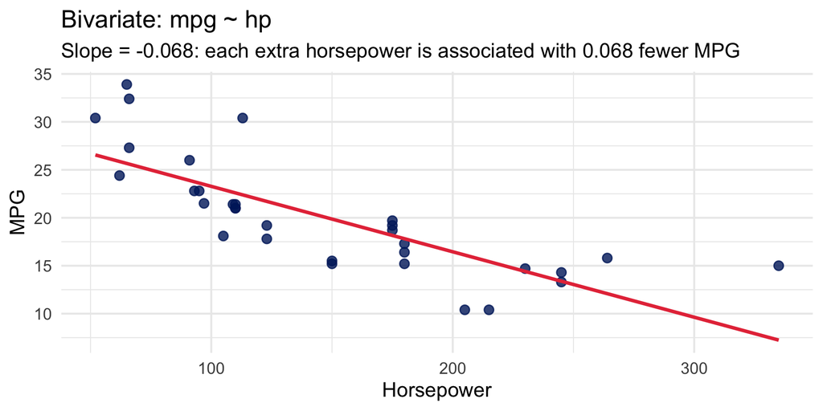

The familiar 2D picture from Unit 4: the best line through the horsepower–MPG points, **ignoring weight**. But every car also has a weight, so the data really live in **3D**…

## Adding Weight: A Cloud of Points in 3D

[interactive chart not shown]

- Each car is a point in 3D: **horsepower**, **weight**, and **MPG**. Drag to rotate!
- Heavier cars have **more horsepower** (correlation 0.66) and **lower MPG** (correlation -0.87)

## The Bivariate Fit Lives on the Back Wall

[interactive chart not shown]

- Flatten every car against the **back wall** (i.e., ignore weight) and you get the 2D scatter from before: the gray **shadow**
- The bivariate regression fits its line (**red**, slope -0.068) to this shadow, so it can’t separate horsepower from weight

## The Multivariate Fit: A Plane

[interactive chart not shown]

- With two regressors, OLS fits a **plane** (yellow), choosing $\hat{\beta}_0, \hat{\beta}_1, \hat{\beta}_2$ to minimize the squared vertical **residuals** (gray sticks)
- The plane’s slope along horsepower, -0.032, is the effect of horsepower **holding weight fixed**. Its trace on the back wall (**gold**) is much flatter than the **red** bivariate line

## Slicing the Plane: Holding Weight Fixed

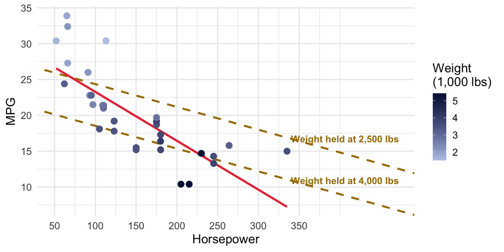

- Back in 2D: each gold line is a **slice of the plane** at a fixed weight, and every slice has the same slope (-0.032). This is what “controlling for weight” means
- Heavier cars (**darker**) have more horsepower *and* lower MPG, so the red bivariate line picks up the effect of weight too

# The Gauss-Markov Assumptions, Revisited

## Gauss-Markov Assumptions (Extended)

1. **Linear in parameters:** $y = \beta_0 + \beta_1 x_1 + \cdots + \beta_k x_k + \mu$
2. **Random sampling**
3. **No perfect multicollinearity** ← UPDATED!
4. **Zero conditional mean:** $E[\mu | x_1, x_2, \ldots, x_k] = 0$ ← UPDATED!
5. **Homoskedasticity:** $Var(\mu | x_1, \ldots, x_k) = \sigma^2$
- Assumptions 1–4 → OLS is **unbiased**; adding 5 gives us the **variance** formula (later today)
- Two assumptions change with multiple regressors. We’ll take them in order: **assumption 3**, then **assumption 4**

## Assumption 3: No Perfect Multicollinearity

- New assumption 3 includes both **variation in $x_j$** and **no perfect multicollinearity**
- **Perfect multicollinearity**: one variable is an exact linear function of others

Examples:

- Including `income_dollars` and `income_thousands` (one = other × 1000)
- Including `parent1_income` + `parent2_income` + `family_income` when family = parent1 + parent2

```r
# Create a perfectly collinear variable
mtcars$hp_doubled <- 2 * mtcars$hp
lm(mpg ~ hp + hp_doubled + wt, data = mtcars) |> coef()
```

```
(Intercept)          hp  hp_doubled          wt
37.22727012 -0.03177295          NA -3.87783074
```

- R drops the collinear variable and gives you `NA` — but you should fix the model!

## Assumption 4: Zero Conditional Mean

$$E[\mu | x_1, x_2, \ldots, x_k] = 0$$

- In words: once we know the $x$’s, the unobserved factors in $\mu$ are **zero on average** — knowing $x_1, \ldots, x_k$ tells us nothing about $\mu$
- Each control we add **moves a factor out of $\mu$** — that’s why GM4 is **more plausible** with multivariate OLS
- If GM 1–4 hold, OLS is **unbiased**: $E[\hat{\beta}_j] = \beta_j$, so $\hat{\beta}_j$ estimates the **ceteris paribus (causal)** effect of $x_j$

Two examples: one where a control makes GM4 **hold**, and one where it **helps but isn’t enough**.

## Example 1: A Control That Makes GM4 Hold

Suppose crop yield depends on fertilizer, soil quality, rainfall, and pure luck (pests, hail):

**Bivariate:** $yield = \beta_0 + \beta_1 fertilizer + \mu$

$\mu$ contains: **soil quality**, **rainfall**, luck

→ farmers with better soil and more rain also use more fertilizer, so GM4 **fails**

**Multivariate:** $yield = \beta_0 + \beta_1 fertilizer + \beta_2 soil + \beta_3 rain + \mu$

$\mu$ contains: luck

→ luck is unrelated to how much fertilizer a farmer uses, so GM4 **holds**

- Controlling for soil quality and rainfall **pulls both confounders out of $\mu$**
- What’s left in $\mu$ (luck) is uncorrelated with fertilizer, so $\hat{\beta}_1$ is **unbiased**: the ceteris paribus effect of fertilizer

## Example 2: A Control That Isn’t Enough

**Bivariate:** $wage = \beta_0 + \beta_1 educ + \mu$

$\mu$ contains: **family income**, ability, motivation, …

→ family income and ability are correlated with $educ$, so GM4 **fails**

**Multivariate:** $wage = \beta_0 + \beta_1 educ + \beta_2 faminc + \mu$

$\mu$ contains: ability, motivation, …

→ family income has been **pulled out of $\mu$**; ability is still a concern

- Unlike soil and rainfall, the main confounders here (ability, motivation) are **hard to measure**, so we can’t just add them as controls
- Controlling for family income makes GM4 **more plausible**, but it probably still **fails**: $\hat{\beta}_1$ is likely still biased by ability

## When Does Zero Conditional Mean Hold?

**More plausible when:**

- We include key confounders
- Good theoretical motivation for controls
- Rich set of observable controls

**Less plausible when:**

- Important confounders are unobservable (ability, motivation)
- Wrong functional form

**A Warning**

Adding controls helps but **doesn’t guarantee** causality. Unobservable confounders can always lurk in $\mu$.

## What is Bias?

- When GM4 fails because we **omit a relevant variable**, our estimate is **biased**. But how should we define bias?
- Recall that an **unbiased** estimator is right on average: $E[\hat{\beta}_1] = \beta_1$. A **biased** one – call it $\tilde{\beta}_1$ – is, on average, the truth **plus something else**:

$$E[\tilde{\beta}_1] = \beta_1 + \text{something else}$$

- Call this *something else* the **bias**:

$$\text{Bias}(\tilde{\beta}_1) = E[\tilde{\beta}_1] - \beta_1$$

- If $\text{Bias} \neq 0$, we are **systematically** over- or under-estimating the true effect
- **Question:** when we omit a variable, what exactly *is* the something else?

## The OVB Formula

To find the *something else*, suppose the **true** model is:

$$y = \beta_0 + \beta_1 x_1 + \beta_2 x_2 + \mu$$

If we estimate the **correct** regression, including $x_2$, we get the **unbiased** $\hat{\beta}$’s:

$$\hat{y} = \hat{\beta}_0 + \hat{\beta}_1 x_1 + \hat{\beta}_2 x_2$$

But if we omit $x_2$, we get the **biased** $\tilde{\beta}$’s:

$$\tilde{y} = \tilde{\beta}_0 + \tilde{\beta}_1 x_1$$

It turns out the *biased* and *unbiased* estimates are linked by a simple formula:

$$\tilde{\beta}_1 = \hat{\beta}_1 + \hat{\beta}_2 \cdot \tilde{\delta}_1$$

where $\tilde{\delta}_1$ comes from regressing $x_2$ on $x_1$:

$$\quad x_2 = \tilde{\delta}_0 + \tilde{\delta}_1 x_1$$

## The OVB Formula

- Taking expectations, we see that:

$$E[\tilde{\beta}_1] = E[\hat{\beta}_1 + \hat{\beta}_2 \cdot \tilde{\delta}_1]$$

$$E[\tilde{\beta}_1] = E[\hat{\beta}_1] + E[\hat{\beta}_2] \cdot \tilde{\delta}_1$$

- Since $E[\hat{\beta}_1] = \beta_1$ and $E[\hat{\beta}_2] = \beta_2$:

$$E[\tilde{\beta}_1] = \beta_1 + \beta_2 \cdot \tilde{\delta}_1$$

- So the *something else* – the bias – is:

$$Bias(\tilde{\beta}_1) = E[\tilde{\beta}_1] - \beta_1 = \beta_2 \cdot \tilde{\delta}_1$$

$$\underbrace{Bias(\tilde{\beta}_1)}_{\text{What we get wrong}} = \underbrace{\beta_2}_{\text{Relationship of omitted with } y} \times \underbrace{\tilde{\delta}_1}_{\text{Relationship of omitted with } x_1}$$

## Signing the Bias

The bias depends on **two things** — and you can figure out the direction!

|  | $Corr(x_1, x_2) > 0$ | $Corr(x_1, x_2) < 0$ |
| --- | --- | --- |
| $\beta_2 > 0$ | **Positive** bias ↑ | **Negative** bias ↓ |
| $\beta_2 < 0$ | **Negative** bias ↓ | **Positive** bias ↑ |

- Positive × Positive = Positive ($E[\tilde{\beta_1}] = \beta_1 + (+)$ - on average you *overestimate* true effect)
- Positive × Negative = Negative ($E[\tilde{\beta_1}] = \beta_1 + (-)$ - on average you *underestimate* true effect)

**Zero Bias When…**

If **either** $\beta_2 = 0$ (omitted variable doesn’t affect $y$) **or** $\tilde{\delta}_1 = 0$ (omitted variable uncorrelated with $x_1$), there is **no bias**.

## Seeing OVB in Action: The Setup

Let’s **simulate** OVB. Because we write the data-generating process (DGP) ourselves, we **know** the true $\beta_1 = 2$:

```r
set.seed(123)
n <- 10000

# True DGP: y = 3 + 2*x1 + 4*x2 + 3*x3 + error
x2 <- rnorm(n)
x3 <- rnorm(n)                     # x3 is independent of x1
x1 <- -0.5 * x2 + rnorm(n)         # x1 and x2 are NEGATIVELY correlated
y  <- 3 + 2 * x1 + 4 * x2 + 3 * x3 + rnorm(n)
```

**Predict before we run it:** what happens to $\tilde{\beta}_1$ if we leave out $x_2$?

- $\beta_2 = 4 > 0$: $x_2$ raises $y$ → **(+)**
- $Corr(x_1, x_2) < 0$: $\tilde{\delta}_1$ will be negative → **(−)**
- **Bias** $= (+) \times (-) = (-)$: the naive estimate of $\beta_1$ should be **too small**

## Seeing OVB in Action: Does the Formula Work?

```r
full  <- lm(y ~ x1 + x2 + x3)   # correct model
naive <- lm(y ~ x1)             # omits x2 (and x3)
b1    <- function(model) unname(coef(model)["x1"])   # pull out the coefficient on x1

delta1         <- coef(lm(x2 ~ x1))["x1"]   # slope from regressing x2 on x1
predicted_bias <- 4 * delta1                # OVB formula: beta2 (= 4, from the DGP) times delta1
actual_bias    <- b1(naive) - 2             # naive estimate minus the truth
```

| Model | $\hat{\beta}_1$ |
| --- | --- |
| Truth | 2.000 |
| Full model | 1.982 |
| Naive (omit $x_2$) | 0.421 |

| Quantity | Sign | Value |
| --- | --- | --- |
| $\beta_2$ (effect of $x_2$ on $y$) | (+) | 4.000 |
| $\tilde{\delta}_1$ (regress $x_2$ on $x_1$) | (−) | -0.389 |
| Predicted bias $= \beta_2 \times \tilde{\delta}_1$ | (+) × (−) = (−) | -1.556 |
| Actual bias $= \tilde{\beta}_1 - \beta_1$ | (−) | -1.579 |

- The naive estimate is **far below** the truth: **negative** bias, just as we predicted. The full model gets it right (≈ 2)
- The formula works: $\tilde{\beta}_1 \approx \beta_1 + \beta_2 \tilde{\delta}_1 = 2 + (4)(-0.39) = 0.44$, and the naive regression gave **0.42**
- The naive model also omits $x_3$, but $x_3$ is **uncorrelated** with $x_1$ (condition 2 fails), so it adds **no** bias

## Example: Positive Bias — The Gender Wage Gap

A made-up example where we **know** the truth:

**True model:** $\quad wage = \beta_0 + \beta_1(female) + \beta_2(office) + \mu$, with $\beta_1 = -5{,}000$ and $\beta_2 = 20{,}000$

**What we estimate (omitting office):** $\quad \widetilde{wage} = \tilde{\beta}_0 + \tilde{\beta}_1(female)$

- **Omitted variable:** working in an office job
- $\beta_2$ (effect of an office job on wages): **Positive** (+$20,000)
- $\tilde{\delta}_1$ (slope from regressing $office$ on $female$): **Positive**. Say 70% of women and 40% of men work in office jobs. With a 0/1 regressor, the slope is the difference in averages: $0.70 - 0.40 = 0.30$

$$\text{Bias} = \beta_2 \times \tilde{\delta}_1 = 20{,}000 \times 0.30 = +6{,}000$$

> So $E[\tilde{\beta}_1] = -5{,}000 + 6{,}000 = +1{,}000$: on average, the naive regression says women earn **more** than men. Omitting occupation **flips the sign** of the gender gap!

## Example: Negative Bias — Tutoring and Exams

**True model:** $\quad exam = \beta_0 + \beta_1(tutoring\_hours) + \beta_2(prior\_GPA) + \mu$

**What we estimate (omitting prior GPA):** $\quad \widetilde{exam} = \tilde{\beta}_0 + \tilde{\beta}_1(tutoring\_hours)$

- **Omitted variable:** prior GPA (how well the student was already doing)
- $\beta_2$ (effect of prior GPA on exam scores): **Positive** (stronger students score higher)
- $\tilde{\delta}_1$ (slope from regressing $prior\_GPA$ on $tutoring\_hours$): **Negative** (struggling students are the ones who go to tutoring)

$$\text{Bias} = (+) \times (-) = \text{Negative}$$

> The naive estimate **understates** the benefit of tutoring. It can even make tutoring look *harmful*, because the students who use it were already doing worse.

## Class Activity: Sign the Bias!

**🤔 Think-Pair-Share**

For each scenario, determine the **direction** of the omitted variable bias:

1. **Model:** $health = \beta_0 + \beta_1(exercise) + \mu$. Omitted: income.
   - Higher income → more exercise? Higher income → better health?
2. **Model:** $test\_score = \beta_0 + \beta_1(class\_size) + \mu$. Omitted: school funding.
   - More funding → smaller classes? More funding → higher scores?

## Sign the Bias: Answers

Bias $= \beta_2 \times \tilde{\delta}_1$:

1. **Exercise → health, omitting income:** higher income → better health ($\beta_2 > 0$) and more exercise ($\tilde{\delta}_1 > 0$). Bias $= (+)(+) =$ **positive**: overstates the benefit of exercise
2. **Class size → test scores, omitting funding:** more funding → higher scores ($\beta_2 > 0$) and smaller classes ($\tilde{\delta}_1 < 0$). Bias $= (+)(-) =$ **negative**: $\tilde{\beta}_1$ is too negative, so smaller classes look *more* beneficial than they are

# Goodness of Fit: Adjusted R²

## The Problem with R², and the Fix

- **Problem:** $R^2$ can **never decrease** when you add more variables — even irrelevant ones!
- **Fix:** the **adjusted** $R^2$ penalizes for the number of regressors $k$: $\quad \bar{R}^2 = 1 - \dfrac{(1 - R^2)(n - 1)}{n - k - 1}$

```r
set.seed(42)
noise <- matrix(rnorm(nrow(mtcars) * 10), ncol = 10)   # 10 pure-noise variables
small <- summary(lm(mpg ~ hp + wt, data = mtcars))
big   <- summary(lm(mpg ~ hp + wt + noise, data = mtcars))
c("R²"     = small$r.squared,     "R² with noise"     = big$r.squared)
```

```
           R² R² with noise
    0.8267855     0.8507958
```

```r
c("Adj R²" = small$adj.r.squared, "Adj R² with noise" = big$adj.r.squared)
```

```
           Adj R² Adj R² with noise
        0.8148396         0.7565616
```

- $R^2$ went **up** even though the noise variables are meaningless; adjusted $R^2$ went **down**, correctly penalizing them
- **Rule of thumb:** use **adjusted** $R^2$ to compare **fit** — but for **causal** questions, choose controls by whether they’re **confounders**, not by fit

# Variance of the Multivariate OLS Estimator

## Step 1: Recall the Bivariate Variance

Under GM 1–5, the bivariate OLS slope has variance

$$Var(\hat{\beta}_1) = \frac{\sigma^2}{SST_x}, \qquad SST_x = \sum_{i=1}^{n}(x_i - \bar{x})^2$$

- **Numerator, $\sigma^2$:** how noisy the unobserved factors in $\mu$ are → more noise, **less** precision
- **Denominator, $SST_x$:** the total variation in $x$ → more spread in $x$ (or a bigger $n$) gives more information about the slope, **more** precision

In the multivariate case, the same idea applies, but with a twist: **not all of the variation in $x_j$ is useful**.

## Step 2: How Much of $x_j$’s Variation Is Its Own?

- Some variation in $x_j$ is **shared** with the other regressors — OLS can’t tell whether that shared variation moves $y$ through $x_j$ or through the other controls
- Only the variation in $x_j$ that is **independent of the other regressors** identifies $\hat{\beta}_j$

To measure it, regress $x_j$ on **all the other regressors** and record the R-squared, $R_j^2$:

- $R_j^2$ = share of $x_j$’s variation that is **shared** with the other controls
- $1 - R_j^2$ = share that is **independent**

**Example:** in `mpg ~ hp + wt`, how much of horsepower’s variation is shared with weight?

```r
r2_hp <- summary(lm(hp ~ wt, data = mtcars))$r.squared
r2_hp
```

```
[1] 0.4339488
```

About **43%** of the variation in hp is shared with weight, so only **57%** is left to identify the effect of hp.

## Step 3: Swap In the Independent Variation

- **Total** variation in $x_j$: $\quad SST_j = \sum_{i=1}^{n}(x_{ji} - \bar{x}_j)^2$
- **Independent** variation in $x_j$: $\quad SST_j \times (1 - R_j^2)$

Replace $SST_x$ in the bivariate formula with the independent variation:

$$Var(\hat{\beta}_1) = \frac{\sigma^2}{SST_x} \quad \Longrightarrow \quad Var(\hat{\beta}_j) = \frac{\sigma^2}{SST_j(1 - R_j^2)}$$

- If $x_j$ is uncorrelated with the other regressors, $R_j^2 = 0$ and we are back to the bivariate formula
- The factor $\frac{1}{1 - R_j^2}$ is how much collinearity **inflates** the variance. For hp: $\frac{1}{1 - 0.43} \approx 1.77$, so the variance is about 77% larger than if hp were uncorrelated with weight
- **Imperfect multicollinearity** (high but not perfect correlation among the $x$’s) is *allowed*, but as $R_j^2 \rightarrow 1$, $Var(\hat{\beta}_j) \rightarrow \infty$: highly correlated controls are hard to **separate**, so their estimates are imprecise

## What Increases Variance?

Under GM 1–5:
$$Var(\hat{\beta}_j) = \frac{\sigma^2}{SST_j(1 - R_j^2)}$$

Three things **increase** variance: **more noise** ($\sigma^2$ ↑), **less variation in $x_j$** ($SST_j$ ↓), **higher collinearity** ($R_j^2$ ↑).

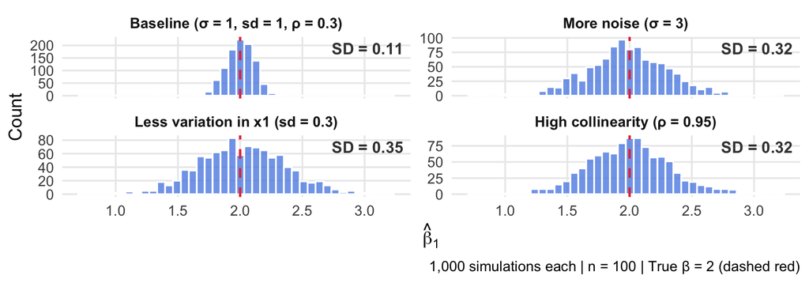

# Estimating $\sigma^2$ and the Standard Error

## Step 1: $\sigma^2$ Is the Average Squared Error

We can compute $SST_j$ and $R_j^2$ from our data, but $\sigma^2 = Var(\mu | x_1, \ldots, x_k)$ is a **population parameter** we never observe. We estimate it in **three steps**: (1) write $\sigma^2$ as an **average**, (2) find a **sample stand-in**, (3) **correct** the stand-in, which is too small

From the Gauss-Markov assumptions:

- **GM4:** $E[\mu_i] = 0$ $\qquad$ **GM5:** $Var(\mu_i) = \sigma^2$

From the stats review, the definition of variance is $Var(X) = E\big[(X - E[X])^2\big]$. Apply it to $\mu_i$:

$$\sigma^2 = Var(\mu_i) = E\big[(\mu_i - E[\mu_i])^2\big] = E\big[(\mu_i - 0)^2\big] = E[\mu_i^2]$$

- $\sigma^2$ is just the **average squared error**
- If we could see the errors, the natural estimate would be their sample average: $\; \dfrac{1}{n}\sum_{i=1}^{n} \mu_i^2$

## Step 2: Residuals as Proxies for Errors

**Problem:** we can’t see $\mu_i$ — computing it requires the **population** $\beta$’s, which is the whole reason we’re running a regression!

- **True error:** $\quad \mu_i = y_i - (\beta_0 + \beta_1 x_{1i} + \dots + \beta_k x_{ki})$ — uses the **unknown** $\beta$’s
- **Residual:** $\quad \hat{\mu}_i = y_i - (\hat{\beta}_0 + \hat{\beta}_1 x_{1i} + \dots + \hat{\beta}_k x_{ki})$ — uses our **estimates**
- **The Solution: Use the residuals:** $\; \dfrac{1}{n}\sum_{i=1}^{n} \hat{\mu}_i^2 = \dfrac{SSR}{n}$
- But the residuals are **systematically smaller** than the true errors: OLS *chooses* the $\hat{\beta}$’s to make $\sum \hat{\mu}_i^2$ as small as possible — smaller than $\sum \mu_i^2$ with the true $\beta$’s

## Step 3: The Degrees-of-Freedom Correction

Because the residuals are too small on average, $SSR / n$ **underestimates** $\sigma^2$.

- Recall the first-order conditions from the OLS derivation: the residuals must satisfy **$k + 1$ equations** ($\sum \hat{\mu}_i = 0$ and $\sum x_{ji} \hat{\mu}_i = 0$ for each $j$)
- So only $n - k - 1$ residuals are free to vary — each estimated parameter “uses up” one **degree of freedom**

**Degrees of freedom:** the number of residuals that are **free to vary**, i.e., $n$ minus the number of estimated parameters. **Example:** if 3 residuals must sum to zero and the first two are $+2$ and $-5$, the third **must** be $+3$, so only $3 - 1 = 2$ are free.

The fix: divide by $n - k - 1$ instead of $n$:

$$\hat{\sigma}^2 = \frac{\sum_{i=1}^{n}\hat{\mu}_i^2}{n - k - 1} = \frac{SSR}{n - k - 1}, \qquad E[\hat{\sigma}^2] = \sigma^2 \;\; \text{(unbiased)}$$

**Note**

$\hat{\sigma} = \sqrt{\hat{\sigma}^2}$ is what R reports as **“Residual standard error.”** In the bivariate case ($k = 1$) the denominator is $n - 2$, the $n - 2$ from Unit 4.

## From $\hat{\sigma}$ to the Standard Error

Plug in $\hat{\sigma}^2$ and take the square root to get the **standard error**: the estimated standard deviation of $\hat{\beta}_j$ across repeated samples

$$Var(\hat{\beta}_j) = \frac{\sigma^2}{SST_j(1-R_j^2)} \xrightarrow{\text{estimate } \sigma^2 \text{ with residuals}} se(\hat{\beta}_j) = \frac{\hat{\sigma}}{\sqrt{SST_j(1-R_j^2)}}$$

## Reading the Standard Error in R Output

The **Coefficients** block of `summary(lm_multi)`:

```r
summary(lm_multi)$coefficients
```

```
               Estimate Std. Error   t value     Pr(>|t|)
(Intercept) 37.22727012 1.59878754 23.284689 2.565459e-20
hp          -0.03177295 0.00902971 -3.518712 1.451229e-03
wt          -3.87783074 0.63273349 -6.128695 1.119647e-06
```

Read the `hp` row (we’ll get to `t value` and `Pr(>|t|)` in Unit 6):

- **Estimate:** holding weight constant, each extra horsepower is associated with 0.032 fewer MPG
- **Std. Error:** if we drew many samples of 32 cars and re-ran the regression, $\hat{\beta}_{hp}$ would typically land about **0.009** away from the true $\beta_{hp}$
- The SE is in the **same units** as the estimate (MPG per horsepower), so judge it **relative to the estimate**
- Don’t compare SEs **across** variables with different units: `wt`’s SE (0.633) appears bigger, but only because the units are different

# The Bias-Variance Tradeoff

## Should You Include That Variable?

Adding controls involves a **tradeoff**:

| Action | Bias | Variance |
| --- | --- | --- |
| Omit a **relevant** variable | ↑ Increases | ↓ Decreases |
| Include an **irrelevant** variable | No change | ↑ Increases |

- **Too few controls → bias:** an omitted variable stays in $\mu$. If it affects $y$ ($\beta_2 \neq 0$) **and** moves with $x_1$ ($\tilde{\delta}_1 \neq 0$), then $\text{Bias} = \beta_2 \tilde{\delta}_1 \neq 0$
- **Too many controls → variance:** an unneeded control that moves with $x_1$ raises $R_1^2$, leaving less independent variation in $x_1$, so $Var(\hat{\beta}_1) = \sigma^2 / [SST_1(1 - R_1^2)]$ rises

> Because you can never know *for sure* the true population parameter model, you can never know *for sure* if a control variable is necessary or not!

## Seeing the Tradeoff

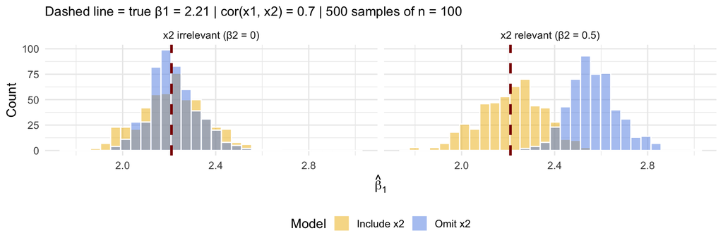

- **Left** ($x_2$ irrelevant): both are centered on the truth, but including $x_2$ (yellow) is **wider**: $x_2$ soaks up some of $x_1$’s variation
- **Right** ($x_2$ relevant): omitting $x_2$ (blue) is **shifted** away from the truth (biased); including it is centered (but wider)

**Key Takeaway**

**Bias is usually worse than variance.** A biased estimate is systematically wrong no matter how much data you collect. Extra variance shrinks with larger samples.

# Summary

## Key Takeaways

- **Multivariate OLS** includes control variables to address confounding: $\; y = \beta_0 + \beta_1 x_1 + \beta_2 x_2 + \cdots + \beta_k x_k + \mu$
- Coefficients have **ceteris paribus** interpretations: the effect of $x_j$ holding all else constant
- **OVB formula** tells us the direction of bias: $\text{Bias} = \beta_2 \cdot \tilde{\delta}_1$
- **Variance:** $Var(\hat{\beta}_j) = \sigma^2 / [SST_j(1 - R_j^2)]$; estimate $\sigma^2$ with $SSR/(n - k - 1)$ to get $se(\hat{\beta}_j)$
- **Bias-variance tradeoff:** omitting relevant variables → bias; including irrelevant variables → extra variance
- **Adjusted R²** penalizes for extra variables — use it to compare fit, not to choose controls
- **Perfect multicollinearity** breaks OLS; imperfect multicollinearity inflates variance

**Next — Unit 6: Statistical Inference.** We’ll finally be able to answer: “Is this coefficient **statistically significant**?”

EC325 | Unit 5 | Multivariate Regression and OLS